# Movie Recommendation

Cheng Wei and Delong Meng

Fall 2021

# Data set and Goal

The data set contains about 1 million anonymous ratings of approximately 3,900 movies made by 6,040 MovieLens users who joined MovieLens in 2000.

#### movies.dat

`movies.dat` file contains movie information.

- `MovieID`: the movie identification number.
- `Title`: movie title.
- `Genres`: movie genres.

#### ratings.dat

`ratings.dat` file contains user rating information.

- `UserID`: the user identification number.
- `MovieID`: the movie identification number.
- `Rating`: the rating the user gives to the movie. It is NA when it is not rated.
- `Timestamp`: the time the rating was given.

#### user.dat

`user.dat` file contains user information.

- `UserID`: the user identification number.
- `Gender`: the user’s gender, ‘M’ for male and ‘F’ for female.
- `Age`: the user’s age range(1: “Under 18”, 18: “18-24”, 25: “25-34”, 35: “35-44”, 45: “45-49”, 50: “50-55”, 56: “56+”).
- `Occupation`: the user’s occupation(0: “other” or not specified, 1: “academic/educator”, 2: “artist”, 3: “clerical/admin”, 4: “college/grad student”, 5: “customer service”, 6: “doctor/health care”, 7: “executive/managerial”, 8: “farmer”, 9: “homemaker”, 10: “K-12 student”, 11: “lawyer”, 12: “programmer”, 13: “retired”, 14: “sales/marketing”, 15: “scientist”, 16: “self-employed”, 17: “technician/engineer”, 18: “tradesman/craftsman”, 19: “unemployed”, 20: “writer”).
- `Zip-code`: the user’s zip-code.

The goal is to learn relevant recommender system algorithms and how to apply to the real world problem.

# System I

```r
library(recommenderlab)
library(Matrix)
library(tidyverse)
library(data.table)
library(dplyr)
```

We load ratings data, `ratings.dat`.

```r
ratings = read.csv(
  file = 'ratings.dat',
  sep = ':',
  colClasses = c('integer', 'NULL'),
  header = FALSE)
colnames(ratings) = c('UserID', 'MovieID', 'Rating', 'Timestamp')
ratings = as_tibble(ratings)
```

```r
head(ratings)
```

| UserID | MovieID | Rating | Timestamp |
| --- | --- | --- | --- |
| 1 | 1193 | 5 | 978300760 |
| 1 | 661 | 3 | 978302109 |
| 1 | 914 | 3 | 978301968 |
| 1 | 3408 | 4 | 978300275 |
| 1 | 2355 | 5 | 978824291 |
| 1 | 1197 | 3 | 978302268 |

We load movies data, `movies.dat`.

```r
movies = readLines('movies.dat')
movies = strsplit(movies, split = "::", fixed = TRUE, useBytes = TRUE)
movies = matrix(unlist(movies), ncol = 3, byrow = TRUE)
movies = data.frame(movies, stringsAsFactors = FALSE)
colnames(movies) = c('MovieID', 'Title', 'Genres')
movies$MovieID = as.integer(movies$MovieID)

# convert accented characters
movies$Title = iconv(movies$Title, "latin1", "UTF-8")

# extract year
movies$Year = as.numeric(unlist(
  lapply(movies$Title, function(x) substr(x, nchar(x)-4, nchar(x)-1))))
movies = as_tibble(movies)
```

```r
head(movies)
```

| MovieID | Title | Genres | Year |
| --- | --- | --- | --- |
| 1 | Toy Story (1995) | Animation\|Children's\|Comedy | 1995 |
| 2 | Jumanji (1995) | Adventure\|Children's\|Fantasy | 1995 |
| 3 | Grumpier Old Men (1995) | Comedy\|Romance | 1995 |
| 4 | Waiting to Exhale (1995) | Comedy\|Drama | 1995 |
| 5 | Father of the Bride Part II (1995) | Comedy | 1995 |
| 6 | Heat (1995) | Action\|Crime\|Thriller | 1995 |

We apply one-hot encoding to the genres for each movie.

```r
genres = as.data.frame(movies$Genres, stringsAsFactors=FALSE)
tmp = as.data.frame(tstrsplit(genres[,1], '[|]',
                              type.convert=TRUE),
                    stringsAsFactors=FALSE)
genre_list = c("Action", "Adventure", "Animation",
               "Children's", "Comedy", "Crime",
               "Documentary", "Drama", "Fantasy",
               "Film-Noir", "Horror", "Musical",
               "Mystery", "Romance", "Sci-Fi",
               "Thriller", "War", "Western")
m = length(genre_list)
genre_matrix = matrix(0, nrow(movies), length(genre_list))
for(i in 1:nrow(tmp)){
  genre_matrix[i,genre_list %in% tmp[i,]]=1
}
colnames(genre_matrix) = genre_list
remove("tmp", "genres")
genre_matrix[1:10,1:5]
```

```
##       Action Adventure Animation Children's Comedy
##  [1,]      0         0         1          1      1
##  [2,]      0         1         0          1      0
##  [3,]      0         0         0          0      1
##  [4,]      0         0         0          0      1
##  [5,]      0         0         0          0      1
##  [6,]      1         0         0          0      0
##  [7,]      0         0         0          0      1
##  [8,]      0         1         0          1      0
##  [9,]      1         0         0          0      0
## [10,]      1         1         0          0      0
```

We concatenate the movies and their genres one-hot encoding together. Then we display and check one-hot encoding is done correctly.

```r
movies_genre = cbind(movies, genre_matrix)
```

```r
head(movies_genre)
```

|  | MovieID | Title | Genres | Year | Action | Adventure | Animation | Children's | Comedy | Crime | Documentary | Drama | Fantasy | Film-Noir | Horror | Musical | Mystery | Romance | Sci-Fi | Thriller | War | Western |
| --- | --- | --- | --- | --- | --- | --- | --- | --- | --- | --- | --- | --- | --- | --- | --- | --- | --- | --- | --- | --- | --- | --- |
| 1 | 1 | Toy Story (1995) | Animation\|Children's\|Comedy | 1995 | 0 | 0 | 1 | 1 | 1 | 0 | 0 | 0 | 0 | 0 | 0 | 0 | 0 | 0 | 0 | 0 | 0 | 0 |
| 2 | 2 | Jumanji (1995) | Adventure\|Children's\|Fantasy | 1995 | 0 | 1 | 0 | 1 | 0 | 0 | 0 | 0 | 1 | 0 | 0 | 0 | 0 | 0 | 0 | 0 | 0 | 0 |
| 3 | 3 | Grumpier Old Men (1995) | Comedy\|Romance | 1995 | 0 | 0 | 0 | 0 | 1 | 0 | 0 | 0 | 0 | 0 | 0 | 0 | 0 | 1 | 0 | 0 | 0 | 0 |
| 4 | 4 | Waiting to Exhale (1995) | Comedy\|Drama | 1995 | 0 | 0 | 0 | 0 | 1 | 0 | 0 | 1 | 0 | 0 | 0 | 0 | 0 | 0 | 0 | 0 | 0 | 0 |
| 5 | 5 | Father of the Bride Part II (1995) | Comedy | 1995 | 0 | 0 | 0 | 0 | 1 | 0 | 0 | 0 | 0 | 0 | 0 | 0 | 0 | 0 | 0 | 0 | 0 | 0 |
| 6 | 6 | Heat (1995) | Action\|Crime\|Thriller | 1995 | 1 | 0 | 0 | 0 | 0 | 1 | 0 | 0 | 0 | 0 | 0 | 0 | 0 | 0 | 0 | 1 | 0 | 0 |

We join movies and rating data-frame together.

```r
movies_ratings = ratings %>% right_join(movies_genre, by = c('MovieID'))
```

```r
movies_n_ratings = movies_ratings %>%
  group_by(MovieID) %>%
  summarize(n_ratings = n())
```

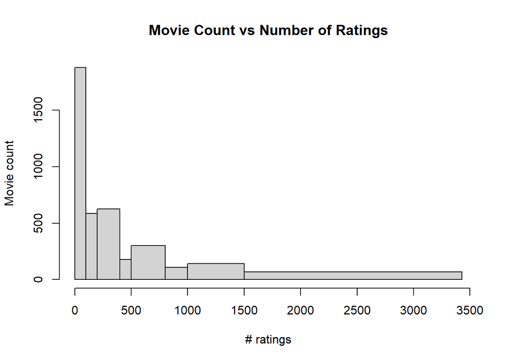

```r
hist(x = movies_n_ratings$n_ratings,
     breaks = c(min(movies_n_ratings$n_ratings), 100, 200, 400, 500, 800, 1000, 1500, max(movies_n_ratings$n_ratings)),
     freq=TRUE,
     xlab = "# ratings",
     ylab = "Movie count",
     main = "Movie Count vs Number of Ratings")
```

We define functions, `top_movies_by_avg_rating` and `top_movies_by_sum_rating` to calculate top n movies for each genre by average ratings and by sum of ratings respectively. The utility function `movies_filter_by_genre` is defined to extract relevant movies for a given genre.

```r
movies_filter_by_genre = function(movies_data, genre) {
  movies_data[movies_data[[genre]]==1,]
}

top_movies_by_sum_rating = function(movies_data, n=5) {
  top_n = function(genre) {
    movies_genre = movies_filter_by_genre(movies_data = movies_data, genre = genre)
    top_movies = movies_genre %>%
      group_by(MovieID) %>%
      summarize(sum_rating = sum(Rating, na.rm = TRUE)) %>%
      arrange(desc(sum_rating))
    top_movies$MovieID[1:n]
  }

  sapply(genre_list, top_n, simplify = TRUE)
}

top_movies_by_avg_rating = function(movies_data, n=5) {
  top_n = function(genre) {
    movies_genre = movies_filter_by_genre(movies_data = movies_data, genre = genre)
    top_movies = movies_genre %>%
      group_by(MovieID) %>%
      summarize(avg_rating = mean(Rating, na.rm = TRUE)) %>%
      arrange(desc(avg_rating))
    top_movies$MovieID[1:n]
  }

  sapply(genre_list, top_n, simplify = TRUE)
}
```

## Top movies by sum of ratings

Let us try to recommend the top movies by the sum of ratings.

```r
result_sum = top_movies_by_sum_rating(movies_data = movies_ratings, n = 15)
result_sum[1:5, 1:5]
```

```
##      Action Adventure Animation Children's Comedy
## [1,]    260       260         1       1097   2858
## [2,]   1196      1196      3114          1   1270
## [3,]   1210      1210      2987        919   1197
## [4,]   2028      1198      2355         34   2396
## [5,]   1198       480      3751       3114   1580
```

Top movies favor the movies having large number of ratings.

```r
top_sum_n_ratings = movies_ratings %>%
  filter(MovieID %in% as.vector(result_sum)) %>%
  group_by(MovieID) %>%
  summarize(n_ratings = n(), avg_rating = mean(Rating, na.rm = TRUE))
min(top_sum_n_ratings$n_ratings)
```

```
## [1] 157
```

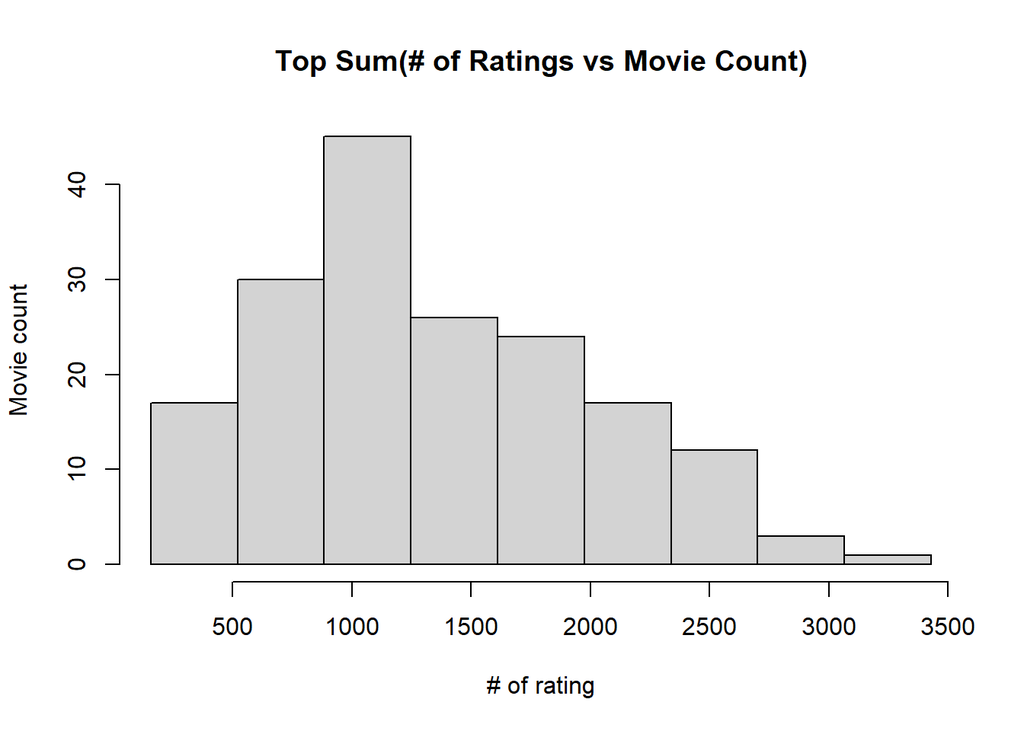

```r
hist(top_sum_n_ratings$n_ratings, xlab = "# of rating", ylab="Movie count", main = "Top Sum(# of Ratings vs Movie Count)",
     breaks = seq(from = min(top_sum_n_ratings$n_ratings), to = max(top_sum_n_ratings$n_ratings), length.out = 10))
```

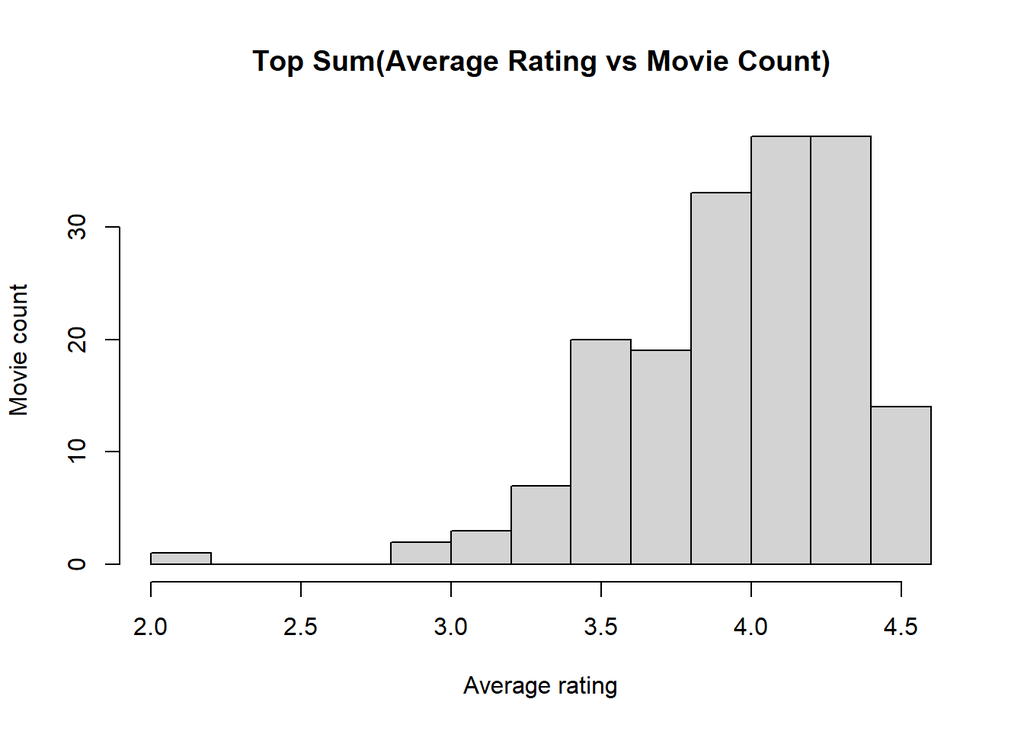

```r
hist(top_sum_n_ratings$avg_rating, xlab = "Average rating", ylab="Movie count", main = "Top Sum(Average Rating vs Movie Count)", )
```

From the plot above, we can see by `top sum` approach, we may include some movies that have high sum of ratings, but their average ratings may not be good.

## Top movies by average rating

Let us try to recommend the top movies by average rating.

```r
result_avg = top_movies_by_avg_rating(movies_data = movies_ratings, n = 15)
movies_ratings %>%
  filter(MovieID %in% as.vector(result_avg)) %>%
  group_by(MovieID) %>%
  summarize(n_ratings = n()) %>%
  filter(n_ratings <= 10)
```

| MovieID | n_ratings |
| --- | --- |
| 53 | 8 |
| 439 | 2 |
| 557 | 2 |
| 578 | 2 |
| 787 | 3 |
| 792 | 1 |
| 989 | 1 |
| 1795 | 2 |
| 1830 | 1 |
| 2309 | 2 |

[output cut: 15 more lines]

We can see from the above that by top average rating approach, we may include the movies having only a few high ratings. This can include some high biased movies. Let us try to filter out the movies that have less than 100 ratings.

```r
movie_ids_above_100_ratings = movies_n_ratings[movies_n_ratings$n_ratings>100,]$MovieID
```

```r
movies_above_100_ratings = movies_ratings %>%
  filter(MovieID %in% movie_ids_above_100_ratings)

result_avg = top_movies_by_avg_rating(movies_data = movies_above_100_ratings, n = 15)
result_avg[1:5, 1:5]
```

```
##      Action Adventure Animation Children's Comedy
## [1,]   2019      1198       745        919    745
## [2,]    858       260      1148       3114   1148
## [3,]   1198      1204       720          1   3030
## [4,]    260      1262      1223       2761   3307
## [5,]   1221      1197      3429       1023   3022
```

Let us check top 1 movies across all genres.

```r
top_avg_n_ratings = movies_ratings %>%
  filter(MovieID %in% as.vector(result_avg)) %>%
  group_by(MovieID) %>%
  summarize(n_ratings = n(), avg_rating = mean(Rating, na.rm = TRUE))
```

```r
movies[match(result_avg[1,], movies$MovieID),] %>%
  left_join(top_avg_n_ratings[, c("MovieID", "avg_rating")], by = "MovieID")
```

| MovieID | Title | Genres | Year | avg_rating |
| --- | --- | --- | --- | --- |
| 2019 | Seven Samurai (The Magnificent Seven) (Shichinin no samurai) (1954) | Action\|Drama | 1954 | 4.560510 |
| 1198 | Raiders of the Lost Ark (1981) | Action\|Adventure | 1981 | 4.477725 |
| 745 | Close Shave, A (1995) | Animation\|Comedy\|Thriller | 1995 | 4.520548 |
| 919 | Wizard of Oz, The (1939) | Adventure\|Children's\|Drama\|Musical | 1939 | 4.247963 |
| 745 | Close Shave, A (1995) | Animation\|Comedy\|Thriller | 1995 | 4.520548 |
| 858 | Godfather, The (1972) | Action\|Crime\|Drama | 1972 | 4.524966 |
| 1147 | When We Were Kings (1996) | Documentary | 1996 | 4.321300 |
| 2019 | Seven Samurai (The Magnificent Seven) (Shichinin no samurai) (1954) | Action\|Drama | 1954 | 4.560510 |
| 260 | Star Wars: Episode IV - A New Hope (1977) | Action\|Adventure\|Fantasy\|Sci-Fi | 1977 | 4.453694 |
| 922 | Sunset Blvd. (a.k.a. Sunset Boulevard) (1950) | Film-Noir | 1950 | 4.491489 |

[output cut: 8 more lines]

```r
cat("minimum number of ratings: ", min(top_avg_n_ratings$n_ratings), "\n")
```

```
## minimum number of ratings:  102
```

```r
cat("minimum average ratings: ", min(top_avg_n_ratings$avg_rating))
```

```
## minimum average ratings:  3.60515
```

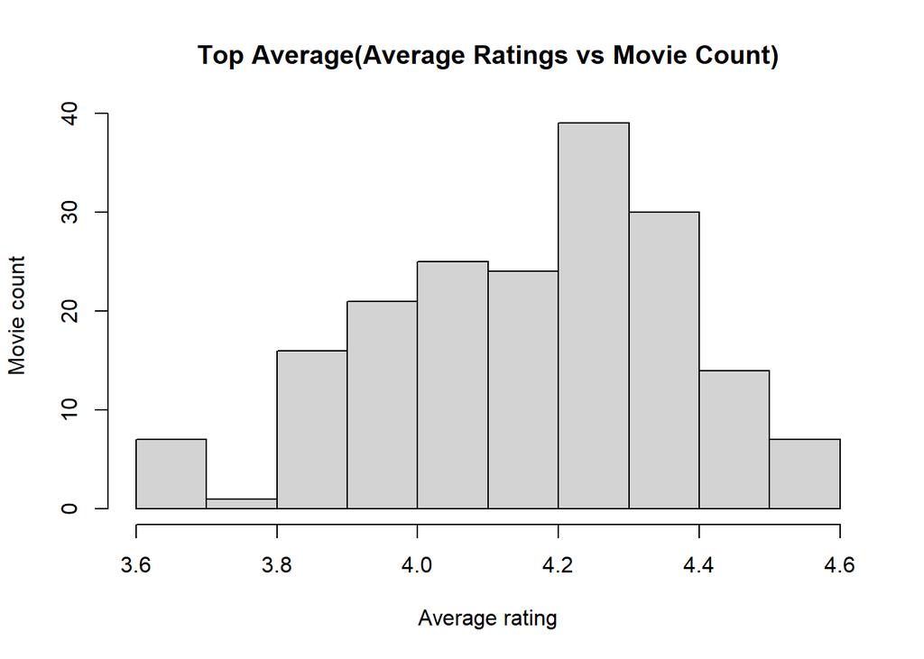

```r
hist(top_avg_n_ratings$avg_rating, xlab = "Average rating", ylab = "Movie count",
     main = "Top Average(Average Ratings vs Movie Count)")
```

From the graph above, we can see the average ratings of the most movies in `top average` movies are above `4.0`. Furthermore, the average value is based on at least `100` ratings, so it is a reasonable way to do the recommendation based on a given genre.

## Top average is selected for System I

Comparing the two approaches, `top sum` and `top average`, `top average` looks more reasonable and `top sum` is biased towards the movies with more ratings.

`top average` movies is picked for System I. Let us write the result of `top average` movies.

```r
write.csv(x = result_avg, file = "top_avg.csv", row.names = FALSE)
```

# System II

```r
library(recommenderlab)
library(Matrix)
library(tidyverse)
library(dplyr)
library(magrittr)
```

We load ratings data `ratings.dat` and convert it to `realRatingMatrix`.

```r
ratings = read.csv(
  file = 'ratings.dat',
  sep = ':',
  colClasses = c('integer', 'NULL'),
  header = FALSE)
colnames(ratings) = c('UserID', 'MovieID', 'Rating', 'Timestamp')

ratings = data.frame(
  UserID = paste0('u', ratings$UserID),
  MovieID = paste0('m', ratings$MovieID),
  Rating = as.double(ratings$Rating))


r_mat = as(ratings, "realRatingMatrix")
```

```r
dim(r_mat)
```

```
## [1] 6040 3706
```

We initialize evaluation scheme and specify the parameters as follows:

- `method`: The evaluation method to use. We use `split` to split the data into train and test data sets.
- `train`: Fraction of the data set used for training. We specify proportion of `0.9` as train data set and the rest `0.1` as test data set.
- `given`: For each user, how many ratings are given to recommender algorithm in evaluation phase. We will give maximal `15` ratings from each user to recommender algorithm and held the rest ratings for evaluating the performance and calculating the errors.
- `k`: The number of times to run the evaluation. We will do `10` runs of random splits.

**Note** that we only use the first `1000` for experiment. This is due to high time-consuming when using the whole data set.

```r
set.seed(0824)

runs = 10

scheme = evaluationScheme(
  data = r_mat[1:1000],
  method="split",
  train=0.9,
  given=15,
  # goodRating=5, # Only keep the ratings greater or equal to the given threshold. This is used with topNList.
  k=runs
)
```

## UBCF

UBCF is a user-based collaborative filtering. It utilizes a specified number of top nearest-neighbor users to predict missing rating values of a given user. UBCF uses a specified similarity measure to find top n nearest-neighbor users.

We tried to tuning the parameters. The following is simplified hyper-grid for demonstration. The original hyper-grid used is `expand.grid(nn = seq(10, 300, 20), method=c("cosine", "pearson"))`.

```r
set.seed(0824)

hyper_grid = expand.grid(nn = c(10, 50, 100, 150, 200, 250), method=c("cosine", "pearson"))
ubcf_output = matrix(0, nrow = nrow(hyper_grid), ncol = 5)
colnames(ubcf_output) = c("nn", "method", "RMSE", "MSE", "MAE")

ubcf_mean_error = function(runs, e, hyper_grid, hyper_i) {
  results = evaluate(scheme, method="UBCF", type = "ratings", progress = FALSE,
           parameter = list(method=as.character(hyper_grid$method[hyper_i]),
                            nn=hyper_grid$nn[hyper_i], weighted=FALSE, normalize="center"))
  result = as.data.frame(do.call(rbind, getConfusionMatrix(results)))
  colMeans(result)
}


for (j in 1:nrow(hyper_grid)) {
  start_time = Sys.time()

  mean_error = ubcf_mean_error(runs = runs, e = e, hyper_grid = hyper_grid, hyper_i = j)

  ubcf_output[j, "nn"] = hyper_grid$nn[j]
  ubcf_output[j, "method"] = as.character(hyper_grid$method[j])
  ubcf_output[j, "RMSE"] = mean_error["RMSE"]
  ubcf_output[j, "MSE"] = mean_error["MSE"]
  ubcf_output[j, "MAE"] = mean_error["MAE"]

  end_time = Sys.time()
  cat("time: ", as.numeric(end_time - start_time, units="secs"), "secs, ", ubcf_output[j,], "\n")
}
```

```
## time:  16.76967 secs,  10 cosine 1.25420730236686 1.57405430334548 0.986017247101926
## time:  19.73773 secs,  50 cosine 1.16054086236158 1.34776067119 0.914137494040443
## time:  22.46393 secs,  100 cosine 1.11236491013534 1.23843145784651 0.878285456449648
## time:  25.92222 secs,  150 cosine 1.06817282207792 1.14196869788267 0.844117067007337
## time:  28.94517 secs,  200 cosine 1.02616941171217 1.05413505906927 0.810757951149372
## time:  32.40144 secs,  250 cosine 1.00208480449198 1.00545232552533 0.791289421928347
## time:  12.175 secs,  10 pearson 1.22223481987203 1.49545006200018 0.959503178796777
## time:  15.24945 secs,  50 pearson 1.08296106481913 1.17428731986132 0.851267635932105
## time:  18.3338 secs,  100 pearson 1.01231630977755 1.0262328350208 0.796380714609651
## time:  21.54671 secs,  150 pearson 0.99051424409979 0.982539073324333 0.779376137464731
## time:  23.41237 secs,  200 pearson 0.983940818735518 0.969567260009826 0.774320503634556
## time:  26.31842 secs,  250 pearson 0.981602918216935 0.964897566729177 0.772697587355409
```

```r
ubcf_output[order(ubcf_output[,"MAE"], decreasing = FALSE),]
```

```
##       nn    method    RMSE                MSE
##  [1,] "250" "pearson" "0.981602918216935" "0.964897566729177"
##  [2,] "200" "pearson" "0.983940818735518" "0.969567260009826"
##  [3,] "150" "pearson" "0.99051424409979"  "0.982539073324333"
##  [4,] "250" "cosine"  "1.00208480449198"  "1.00545232552533"
##  [5,] "100" "pearson" "1.01231630977755"  "1.0262328350208"
##  [6,] "200" "cosine"  "1.02616941171217"  "1.05413505906927"
##  [7,] "150" "cosine"  "1.06817282207792"  "1.14196869788267"
##  [8,] "50"  "pearson" "1.08296106481913"  "1.17428731986132"
##  [9,] "100" "cosine"  "1.11236491013534"  "1.23843145784651"
## [10,] "50"  "cosine"  "1.16054086236158"  "1.34776067119"
## [11,] "10"  "pearson" "1.22223481987203"  "1.49545006200018"
## [12,] "10"  "cosine"  "1.25420730236686"  "1.57405430334548"
##       MAE
##  [1,] "0.772697587355409"
##  [2,] "0.774320503634556"
##  [3,] "0.779376137464731"
##  [4,] "0.791289421928347"
##  [5,] "0.796380714609651"
##  [6,] "0.810757951149372"
##  [7,] "0.844117067007337"
##  [8,] "0.851267635932105"
##  [9,] "0.878285456449648"
## [10,] "0.914137494040443"
## [11,] "0.959503178796777"
## [12,] "0.986017247101926"
```

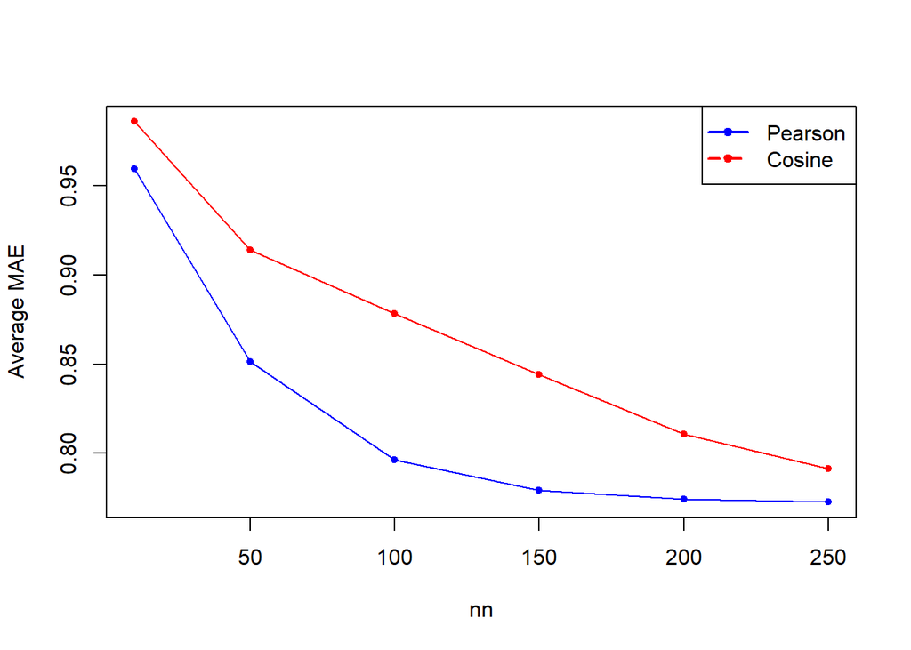

```r
plot_output = function(output, k_or_nn) {
    output_tbl = as_tibble(data.frame(output)) %>%
    mutate_at(.vars = c("RMSE", "MSE", "MAE"), .funs = as.numeric) %>%
    mutate_at(.vars = c(k_or_nn), .funs = as.integer)
  plot(NA, xlim = range(output_tbl[[k_or_nn]]), ylim = range(output_tbl$MAE),
         xlab = k_or_nn, ylab = "Average MAE")

  points(x = output_tbl[output_tbl$method=="pearson",][[k_or_nn]],
         y = output_tbl[output_tbl$method=="pearson",]$MAE,
         col = "blue",
         pch  = 20)
  lines(output_tbl[output_tbl$method=="pearson",][[k_or_nn]],
        output_tbl[output_tbl$method=="pearson",]$MAE , col="blue")

  points(x = output_tbl[output_tbl$method=="cosine",][[k_or_nn]],
         y = output_tbl[output_tbl$method=="cosine",]$MAE,
         col = "red",
         pch  = 20)
  lines(output_tbl[output_tbl$method=="cosine",][[k_or_nn]],
        output_tbl[output_tbl$method=="cosine",]$MAE , col="red")
  legend("topright", c("Pearson", "Cosine"), lty = c(1, 2),
         pch = c(20, 20), lwd = 2, col = c("blue", "red"))
}
plot_output(output = ubcf_output, k_or_nn="nn")
```

Based on the above parameter search, we settled with the following parameters:

- `method`: The method for calculating the similarity between users. We choose `pearson` based on the parameter tuning result. `pearson` resulted in smaller `RMSE` in most cases than `cosine` similarity measure in this case.
- `nn`: Number of top nearest neighbors. We picked 150 top nearest neighbors to inference the missing rating for a given user.
- `weighted`: We disable weighted sum of nearest neighbors ratings. Instead, we use simply average of nearest neighbors ratings. This is because for `pearson` similarity, sum of similarity values in the denominator can be zero in some cases and result in errors in calculation.
- `normalize`: We `center` the rating data by users to remove user biases.

```r
set.seed(0824)
ubcf_results = evaluate(x = scheme, method="UBCF", type = "ratings", progress = TRUE,
                        parameter = list(method="pearson", nn=150, weighted=FALSE, normalize="center"))
```

```
## UBCF run fold/sample [model time/prediction time]
##   1  [0.01sec/2.03sec]
##   2  [0.02sec/1.93sec]
##   3  [0.03sec/1.85sec]
##   4  [0.01sec/1.95sec]
##   5  [0.01sec/2.05sec]
##   6  [0.03sec/2.07sec]
##   7  [0.02sec/1.95sec]
##   8  [0.02sec/1.94sec]
##   9  [0sec/1.87sec]
##   10  [0.02sec/1.91sec]
```

From the evaluation output, we can see that UBCF has a small model time but a long prediction time. For UBCF, there is no training involved and most computation is done in prediction stage. It tries to find top `nn` nearest neighbors given a data point in prediction stage.

```r
ubcf_result = as.data.frame(do.call(rbind, getConfusionMatrix(ubcf_results)))
ubcf_result
```

| RMSE | MSE | MAE |
| --- | --- | --- |
| 1.0087424 | 1.0175612 | 0.7893339 |
| 0.9850211 | 0.9702666 | 0.7763284 |
| 1.0277211 | 1.0562107 | 0.8089888 |
| 0.9564353 | 0.9147685 | 0.7442365 |
| 1.0533641 | 1.1095758 | 0.8305292 |
| 1.0389727 | 1.0794642 | 0.8201911 |
| 0.9320851 | 0.8687826 | 0.7361236 |
| 0.9652289 | 0.9316668 | 0.7547490 |
| 0.9697895 | 0.9404918 | 0.7714316 |
| 0.9677823 | 0.9366026 | 0.7618493 |

```r
colMeans(ubcf_result)
```

```
##      RMSE       MSE       MAE
## 0.9905142 0.9825391 0.7793761
```

## IBCF

IBCF is a item-based collaborative filtering. It utilizes a specified number of top nearest-neighbor items to predict missing rating values of an item in a given user. IBCF uses a specified similarity measure to find top n nearest-neighbor items.

We tried to tuning the parameters. The following is simplified hyper-grid for demonstration. The original hyper-grid used is `expand.grid(k = seq(5, 50, 5), method=c("cosine", "pearson"))`.

```r
set.seed(0824)

hyper_grid = expand.grid(k = seq(5, 50, 10), method=c("cosine", "pearson"))
ibcf_output = matrix(0, nrow = nrow(hyper_grid), ncol = 5)
colnames(ibcf_output) = c("k", "method", "RMSE", "MSE", "MAE")

ibcf_mean_error = function(runs, e, hyper_grid, hyper_i) {
  results = evaluate(scheme, method="IBCF", type = "ratings", progress = FALSE,
           parameter = list(method=as.character(hyper_grid$method[hyper_i]),
                            k=hyper_grid$k[hyper_i], normalize = 'Z-score'))
  result = as.data.frame(do.call(rbind, getConfusionMatrix(results)))
  colMeans(result)
}

for (j in 1:nrow(hyper_grid)) {
  start_time = Sys.time()

  mean_error = ibcf_mean_error(runs = runs, e = e, hyper_grid = hyper_grid, hyper_i = j)

  ibcf_output[j, "k"] = hyper_grid$k[j]
  ibcf_output[j, "method"] = as.character(hyper_grid$method[j])
  ibcf_output[j, "RMSE"] = mean_error["RMSE"]
  ibcf_output[j, "MSE"] = mean_error["MSE"]
  ibcf_output[j, "MAE"] = mean_error["MAE"]

  end_time = Sys.time()
  cat("time: ", as.numeric(end_time - start_time, units="secs"), "secs, ", ibcf_output[j,], "\n")
}
```

```
## time:  302.7074 secs,  5 cosine 1.43377730571115 2.08241157709369 1.07289830277912
## time:  316.0972 secs,  15 cosine 1.44400177320562 2.10343500209544 1.09900081267812
## time:  303.1102 secs,  25 cosine 1.47506472999948 2.19031255045233 1.12858319734349
## time:  341.293 secs,  35 cosine 1.47503714178884 2.19870410023792 1.13132380244392
## time:  322.3627 secs,  45 cosine 1.48429977151055 2.22820842496921 1.1394154170292
## time:  257.8551 secs,  5 pearson 1.39928286984009 2.00019006310335 1.04448059900262
## time:  249.7798 secs,  15 pearson 1.45214996294844 2.12594679701938 1.08805807059531
## time:  232.7603 secs,  25 pearson 1.48164413465662 2.22050270784937 1.11759664852112
## time:  222.3794 secs,  35 pearson 1.50762213407538 2.29120362507069 1.14131061353851
## time:  217.1712 secs,  45 pearson 1.54287196994348 2.39714183848379 1.17011670006266
```

```r
ibcf_output[order(ibcf_output[,"MAE"], decreasing = FALSE),]
```

```
##       k    method    RMSE               MSE                MAE
##  [1,] "5"  "pearson" "1.39928286984009" "2.00019006310335" "1.04448059900262"
##  [2,] "5"  "cosine"  "1.43377730571115" "2.08241157709369" "1.07289830277912"
##  [3,] "15" "pearson" "1.45214996294844" "2.12594679701938" "1.08805807059531"
##  [4,] "15" "cosine"  "1.44400177320562" "2.10343500209544" "1.09900081267812"
##  [5,] "25" "pearson" "1.48164413465662" "2.22050270784937" "1.11759664852112"
##  [6,] "25" "cosine"  "1.47506472999948" "2.19031255045233" "1.12858319734349"
##  [7,] "35" "cosine"  "1.47503714178884" "2.19870410023792" "1.13132380244392"
##  [8,] "45" "cosine"  "1.48429977151055" "2.22820842496921" "1.1394154170292"
##  [9,] "35" "pearson" "1.50762213407538" "2.29120362507069" "1.14131061353851"
## [10,] "45" "pearson" "1.54287196994348" "2.39714183848379" "1.17011670006266"
```

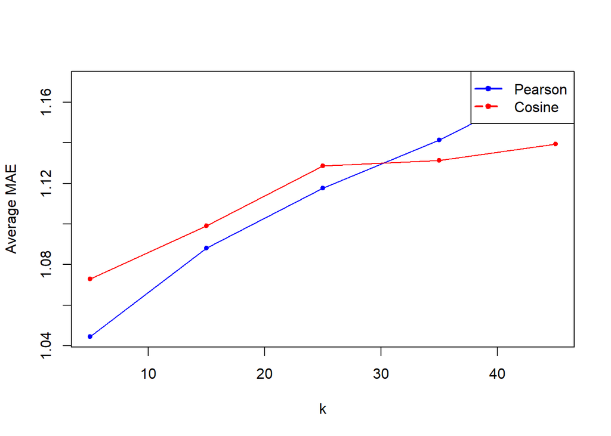

```r
plot_output(output = ibcf_output, k_or_nn="k")
```

Based on the above parameter search, we settled with the following parameters:

- `method`: The method for calculating the similarity between users. We choose `pearson` based on the parameter tuning result, which has smaller `RMSE` than `cosine` when `k=5`.
- `k`: Number of top nearest-neighbor items. We picked `5` top nearest neighbors to inference the missing rating for an item in a given user.
- `normalize`: We `center` the rating data by users to remove user biases.
- `normalize_sim_matrix`: Whether to normalize the similarity matrix so that they are probabilities and each row sum to `1`. We use default value `FALSE`.
- `alpha`: Default to `0.5`.

```r
ibcf_results = evaluate(x = scheme, method="IBCF", type = "ratings", progress = TRUE,
                   parameter = list(method="pearson", k=5, normalize="center"))
```

```
## IBCF run fold/sample [model time/prediction time]
##   1  [21.3sec/0.03sec]
##   2  [21.06sec/0.03sec]
##   3  [21.38sec/0.01sec]
##   4  [21.28sec/0.03sec]
##   5  [21.41sec/0.04sec]
##   6  [21.08sec/0.04sec]
##   7  [21.88sec/0.03sec]
##   8  [21.53sec/0.04sec]
##   9  [21.39sec/0.03sec]
##   10  [21.09sec/0.03sec]
```

From the evaluation output, we can see that IBCF has a big model training time(For calculating an item-to-item similarity matrix) but a small prediction time.

```r
ibcf_result = as.data.frame(do.call(rbind, getConfusionMatrix(ibcf_results)))
ibcf_result
```

| RMSE | MSE | MAE |
| --- | --- | --- |
| 1.655032 | 2.739130 | 1.3043478 |
| 1.381699 | 1.909091 | 1.0259740 |
| 1.289716 | 1.663366 | 0.9504950 |
| 1.236159 | 1.528090 | 0.9101124 |
| 1.465656 | 2.148148 | 1.1111111 |
| 1.517342 | 2.302326 | 1.0465116 |
| 1.164965 | 1.357143 | 0.7936508 |
| 1.215515 | 1.477477 | 0.8648649 |
| 1.256981 | 1.580000 | 0.9000000 |
| 1.547848 | 2.395833 | 1.1041667 |

```r
colMeans(ibcf_result)
```

```
##     RMSE      MSE      MAE
## 1.373091 1.910060 1.001123
```

## SVDF (Future work)

**Notation**

$R$: the real user-item rating matrix.

$R_{i,j}$: the rating value given by user $i$ for movie $j$.

$U_i$: latent factor vector for user $i$.

$M_i$: latent factor vector for movie $j$.

SVDF uses Funk SVD method to calculate missing ratings for a given user. With Funk SVD approach, we tried to make a matrix decomposition $UM^T$, which approximate the real rating matrix $R$ as close as possible. Namely, $R \approx UM^T$. We can define our objective function as minimizing the Sum of Squared Error between predicted rating values and non-empty true rating values. Futuremore, in order to make the model generalize well and prevent over-fitting to training data, we add a penalty term to the objective function.

$$min\Sigma_{i,j}(R_{i,j}-U_iM_j^T)^2+\lambda(||U_i||^2 + ||M_j||^2)\text{, where R_i,j is not empty}$$
When a user does not give many ratings, We would like the length of vectors $U_i$ and $M_j$ to be small and close to origin. This is because we don’t have much information about the user(we will keep $U_i$ and $M_j$ simple) and there are only a few ratings from the user ($(R_{i,j}-U_iM_j^T)^2$ will be small). When a user does give many ratings, we would like to have more complicated $U_i$ and $M_j$ to make $(R_{i,j}-U_iM_j^T)^2$ small and balance with the complexity of $U_i$ and $M_j$. The penalty term $\lambda(||U_i||^2 + ||M_j||^2)$ allows us to achieve it.

With the objective function, we can randomly initialize $U$ and $M$ matrices. Then we can use gradient decent to optimize the objective function to get optimized $U$ and $M$. With $U$ and $M$, we can calculate prediction for missing rating values.

We evaluate the performance of SVDF and specify the parameters as follows:

- `k`: Number of factors. We use default value of `10`.
- `gamma`: Learning rate. We use default value of `0.015`.
- `lambda`: The penalty value that is applied to $U_i$ and $M_i$. When penalty value is big, We would like $U_i$ and $M_j$ to be simple and close to origin. Whereas, when penalty value is small, We would like $U_i$ and $M_j$ to be as complex as possible to make $(R_{i,j}-U_iM_j^T)^2$ small. We use the default value of `0.001`.
- `min_epochs`: Minimum number of epoches. We as least do `min_epochs` of optimizations. We use the default value `50`.
- `max_epochs`: Maximum number of epoches allowed for the optimization. We use the default value `200`.
- `min_improvement`: The minimum improvement for an epoch. If the improvement is below the minimum for an epoch, we stop the further optimization. We use the fault value `1e-06`.
- `normalize`: We `center` the rating data by users to remove user biases.

`SVDF` is too time-consuming for training. We also tried `LIBMF`, which is similar to `SVDF` but it is fast to train. However, currently, `LIBMF` is not well integrated into `recommenderlab`. `LIBMF` from `recommenderlab` does not have `lrate`(learning rate), `niter`(optimization iterations) for example. We will leave it for future study.

```r
svdf_results = evaluate(x = scheme, method="SVDF", type = "ratings", progress = TRUE,
                        parameter = list(k=10, normalize="center"))
```

```r
svdf_result = as.data.frame(do.call(rbind, getConfusionMatrix(svdf_results)))
svdf_result
```

## UBCF is selected for System II

Based on experiments, `UBCF` performed better than `IBCF` in this case, so we chose `UBCF` as the model for the app.

# Team Members

Cheng Wei (chengw5, MCS-DS) and Delong Meng (delongm2, MCS-DS)

#### contributions

- Cheng Wei: Cheng contributed `top average` approach in `System I`. Also, for `System II`. Cheng contributed `UBCF` algorithm and its fine tuning.
- Delong Meng: Delong contributed `top sum` approach in `System I`. Additionally, in `System II`, Delong added `IBCF` algorithm and its fine tuning.
- Cheng and Delong worked together on the app building, and looked into `SVD` and `LIBMF` algorithms for `System II`.